# Advanced Macroeconomics Homework 4

Aryaman Nagpal

2024-02-29

## Problem 1: Developmental Accounting

### 1(a)

We will calculate technology and per-capita income relative to the United States. Define the relative savings rate by $s_{i,t} = \frac{S_{i,t}}{S_{us,t}}$ and relative human capital measure by $h_{i,t} = \frac{H_{i,t}}{H_{us,t}}$. Then, Hall and Jones’ formula can be rewritten as
$$y_{i,t} = \left( s_{i,t}
\right)^{\frac{\alpha}{1-\alpha}}a_{i,t}h_{i,t}$$
Rearranging, we have
$$a_{i,t} =
\frac{y_{i,t}}{h_{i,t}}\left( s_{i,t}
\right)^{-\frac{\alpha}{1-\alpha}}$$
We can now use the given data to calculate and plot $a_{i,t}$ and $y_{i,t}$.

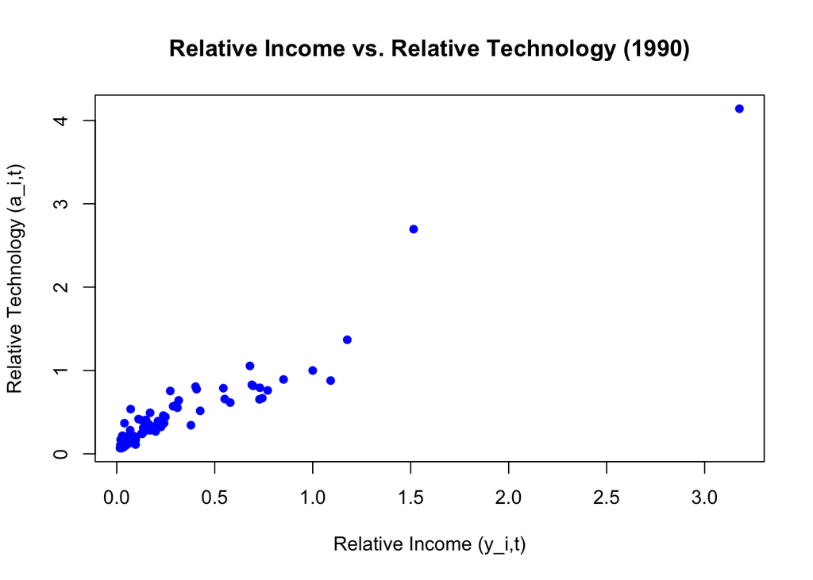

```r
data <- read.table("/Users/aryaman/Downloads/MRW_2015.csv", header = TRUE, sep = "\t")

# Drop major oil producing countries from the data set
data <- data[data$oil == 0, ]

# Calculate relative savings and human capital measure
data$rs1990 <- data$savingsrate1990 /
               data[data$country == "United States", "savingsrate1990"]
data$rs2015 <- data$savingsrate2015 /
               data[data$country == "United States", "savingsrate2015"]
data$rhc1990 <- data$hc1990 /
                data[data$country == "United States", "hc1990"]
data$rhc2015 <- data$hc2015 /
                data[data$country == "United States", "hc2015"]

# Calculate relative income per capita
data$ry1990 <- data$rgdpe1990 /
               data[data$country == "United States", "rgdpe1990"]
data$ry2015 <- data$rgdpe2015 /
               data[data$country == "United States", "rgdpe2015"]

# Calculate relative technology measure
alpha <- 1/3
data$ra1990 <- (data$ry1990 / data$rhc1990) * (data$rs1990)^(-alpha/(1-alpha))
data$ra2015 <- (data$ry2015 / data$rhc2015) * (data$rs2015)^(-alpha/(1-alpha))

plot(data$ry1990, data$ra1990, pch = 16, col = "blue",
     main = "Relative Income vs. Relative Technology (1990)",
     xlab = "Relative Income (y_i,t)", ylab = "Relative Technology (a_i,t)")
```

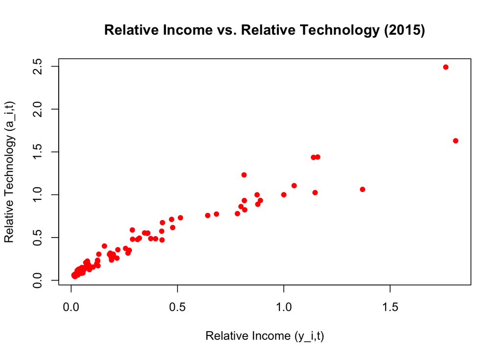

```r
plot(data$ry2015, data$ra2015, pch = 16, col = "red",
     main = "Relative Income vs. Relative Technology (2015)",
     xlab = "Relative Income (y_i,t)", ylab = "Relative Technology (a_i,t)")
```

We observe that in both plots, there is a strong positive relationship between $y_{i,t}$ and $a_{i,t}$. This suggests that countries with living standards relative to the United States also tend to have higher technology measures relative to the United States, and vice-versa.

### 1(b)

In order to reproduce the averages, we will take the geometric means of the four variables in both 1990 and 2015. ‘ry’ represents relative income, ‘rcapintensity’ the relative capital intensity defined as $s_{i,t}^{\alpha/(1-\alpha)}$, ‘rhc’ the relative human capital measure, and ‘ra’ the relative technology measure (all relative to the United States). Let $\alpha = 1/3$, then $\alpha/(1-\alpha) = 1/2$.

```r
data$rcapintensity1990 <- data$rs1990^0.5
data$rcapintensity2015 <- data$rs2015^0.5

sapply(data[, c('ry1990', 'rcapintensity1990', 'rhc1990', 'ra1990')]
              , function(x) exp(mean(log(x))))
```

```
##            ry1990 rcapintensity1990           rhc1990            ra1990
##         0.1364857         0.8009503         0.5611514         0.3036697
```

```r
sapply(data[, c('ry2015', 'rcapintensity2015', 'rhc2015', 'ra2015')]
              , function(x) exp(mean(log(x))))
```

```
##            ry2015 rcapintensity2015           rhc2015            ra2015
##         0.1798114         0.9084818         0.6499240         0.3045358
```

We can calculate the relative importance of each variable by diving the reciprocal of each variable by the sum of the reciprocals of the three variables. For instance, to calculate the relative importance of the relative human capital in explaining differences in relative living standards, we would calculate
$$\frac{\frac{1}{h_{i,t}}}{\frac{1}{(s_{i,t})^{\alpha/(1-\alpha)}}
+ \frac{1}{h_{i,t}} + \frac{1}{a_{i,t}}}$$

In 1990, the average percent difference in per capita income relative to the United States was $1-0.136 = 0.864 = 86.4$%. Out of this, $19.7$% is attributed to differences in capital intensity relative to the US, $28.2$% to relative differences in human capital, and $52.1$% to differences in TFP.

In 2015, the average percent difference in per capita income relative to the United States was $1-0.180=82.0$%. Out of this, $18.6$% can be attributed to differences in capital intensity relative to the US, 26.0% to differences in human capital, and 55.4% to differences in TFP.

We do not observe a substantial difference in the relative importance of these factors in explaining differences in per capita income from 1990 to 2015. In both time periods, technology is by far the most important variable in explaining the average percent difference in living standards.

### 1(c)

```r
sprintf("%.2f%%", 100 * (data[data$country == "China", "ra2015"]
                        / data[data$country == "China", "ra1990"] - 1))
```

```
## [1] "103.73%"
```

The decomposition thus suggests that China’s technology measure more than doubled (an increase of 103.73%) relative to that of the United States across the period 1900 to 2015.

### 1(d)

The TFP Share is defined as
$$share_{i,t}
= \frac{\frac{1}{a_{i,t}}}{\frac{1}{a_{i,t}} +
\frac{1}{h_{i,t}s_{i,t}^{\alpha/(1-\alpha)}}}$$

We will calculate and plot the TFP Share, $share_{i,t}$, for the given data set.

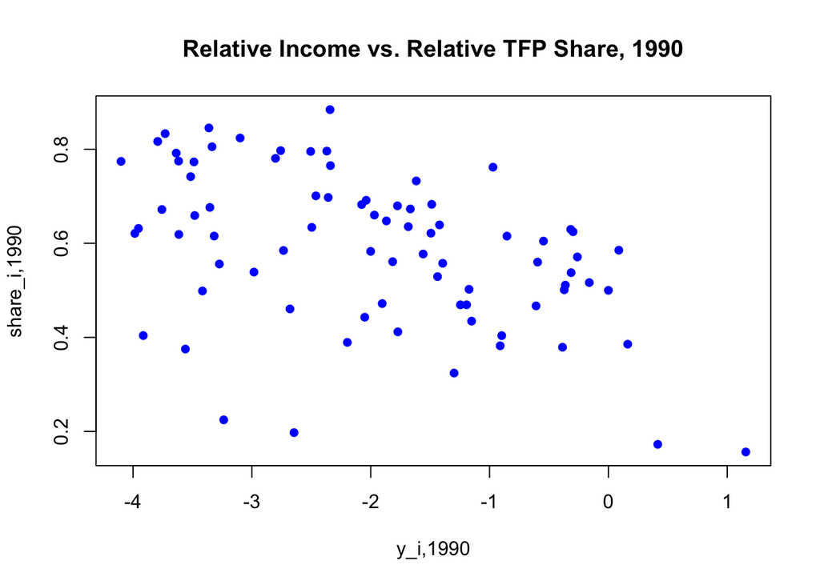

```r
data$tfpshare1990 <- 1 / data$ra1990 / (1 / data$ra1990 + 1 /
                 (data$rhc1990 * data$rs1990^(alpha / (1 - alpha))))

data$tfpshare2015 <- 1 / data$ra2015 / (1 / data$ra2015 + 1 /
                 (data$rhc2015 * data$rs2015^(alpha / (1 - alpha))))

plot(log(data$ry1990), data$tfpshare1990, pch = 16, col = "blue",
     main = "Relative Income vs. Relative TFP Share, 1990",
     xlab = "y_i,1990", ylab = "share_i,1990")
```

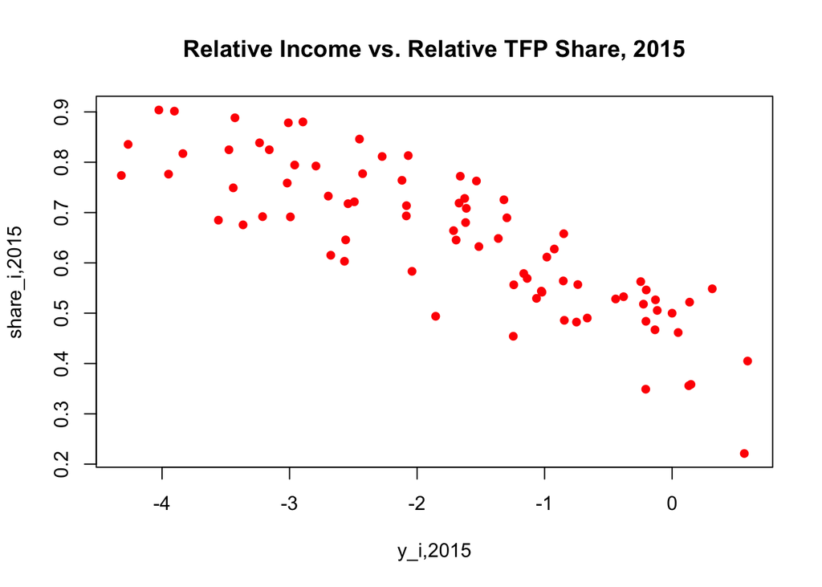

```r
plot(log(data$ry2015), data$tfpshare2015, pch = 16, col = "red",
     main = "Relative Income vs. Relative TFP Share, 2015",
     xlab = "y_i,2015", ylab = "share_i,2015")
```

The plots suggest that a country’s TFP share relative to the United States tends to be lower if the country has higher living standards relative to the United States, and vice-versa. We see this relationship more clearly in the 2015 data as seen by the more obvious clustering of the data points along the negative linear relationship.

### 1(e)

#### 1(e)(i)

To check for convergence in technology, we will first plot $\Delta \ln{(a_i)} = \ln{(a_{i,2015})} - \ln{(a_{i,1990})}$ against $\ln{(a_{i,1990})}$.

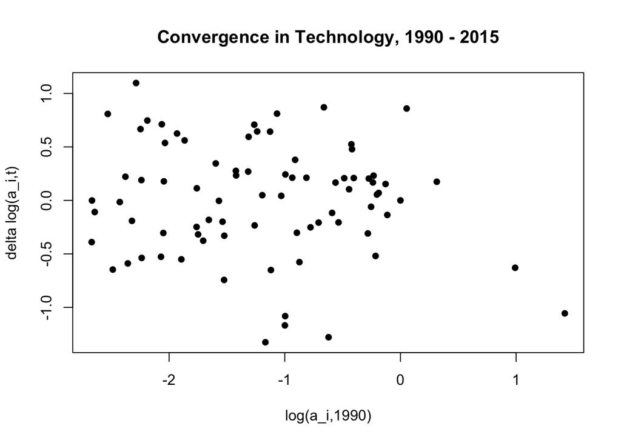

```r
data$delta_log_a <- log(data$ra2015/data$ra1990)

plot(log(data$ra1990), data$delta_log_a, pch = 16,
     main = "Convergence in Technology, 1990 - 2015",
     xlab = "log(a_i,1990)", ylab = "delta log(a_i,t)")
```

There seems to be little evidence for unconditional convergence in the relative technology measure over time in this data since there is no evident relationship between the values in the plot.

#### 1(e)(ii)

Next, we will estimate the relationship
$$\Delta \ln{(a_i)} = \gamma_0 +
\gamma_1\ln{(a_{i,1990})} + \epsilon_i$$
to test for unconditional convergence in the relative technology measure $a_i$.

```r
unconditional_conv_lm <- lm(delta_log_a ~ log(ra1990), data = data)
stargazer(unconditional_conv_lm,
      title = "Unconditional Convergence in Relative Technology", type = 'latex')
```

[output not shown]

As expected, our regression does not find evidence of unconditional convergence in technology relative to the United States. The coefficient on $\ln{(a_{i,1990})}$ is near zero ($\gamma_1 = -0.070$) and has an insignificant p-value. Further, the adjusted $R^2$ is very low at $0.001$, indicating that unconditional convergence in technology is not observed in the data.

#### 1(e)(iii)

Finally, we will estimate the relationship
$$\Delta \ln{(a_i)} = \gamma_0 +
\gamma_1\ln{(a_{i,1990})} + \gamma_2\ln{(h_{i,1990})} +
\epsilon_i$$
to test for convergence in the relative technology measure conditioned on the level of human capital relative to the US.

```r
conditional_conv_lm <- lm(delta_log_a ~ log(ra1990) + log(rhc1990), data = data)
stargazer(conditional_conv_lm, title = "Convergence in Relative Technology,
          Conditioned on Relative Human Capital", type = 'latex')
```

[output not shown]

We now have statistically significant coefficients for both $\ln{(a_{i,1990})}$ and $\ln{(h_{i,1990})}$, suggesting that after controlling for human capital, the countries in the data set do show evidence for convergence in technology relative to the United States. The model suggests that a one percent increase in log human capital relative to the United States tends to increase the change in relative technology from 1990 to 2015 by 1.174%.

Our adjusted $R^2$ value suggests that starting technology and human capital together account for approximately $36.6$% of the variation in how relative technology evolved from 1990 to 2015 across the different countries. Since growth in technology is dependent on another variable in the model, human capital, we should not consider relative technology as an exogenous variable.

## Problem 2: Endogenous Growth

### 2(a)

We know
$$f(g) = \frac{\Delta
g_{t+1}}{g_t} = \frac{g_{t+1} - g_t}{g_t}$$
$$g_t = \frac{A_t - A_{t-1}}{A_{t-1}}$$
Substituting the evolution of technology relationship, we have
$$g_t =
\frac{B(a_LL_{t-1})^{\gamma}A_{t-1}^{\theta}}{A_{t-1}}$$
$$= B(a_LL_{t-1})^{\gamma}A_{t-1}^{\theta-1}
-1$$
Thus,
$$f(g) = \frac{g_{t+1} -
g_t}{g_t} = \frac{g_{t+1}}{g_t} - 1$$
$$=
\frac{B(a_LL_{t})^{\gamma}A_{t}^{\theta-1}}{B(a_LL_{t-1})^{\gamma}A_{t-1}^{\theta-1}}
- 1$$
$$= \left( \frac{L_{t}}{L_{t-1}}
\right)^{\gamma} \left( \frac{A_t}{A_{t-1}} \right)^{\theta-1} -
1$$
Using the fact that
$$\frac{L_t}{L_{t-1}} = 1+n$$
$$\frac{A_t}{A_{t-1}} = 1+g$$
we have
$$f(g) = \left[\left( \frac{L_{t}}{L_{t-1}}
\right)^{\gamma} \left( \frac{A_t}{A_{t-1}} \right)^{\theta-1} -
1\right]$$
$$=
\left[(1+n)^{\gamma}(1+g)^{\theta -1}-1\right]$$
$$= \left[\frac{(1+n)^{\gamma}}{(1+g)^{1-\theta}} -
1\right]$$

### 2(b)

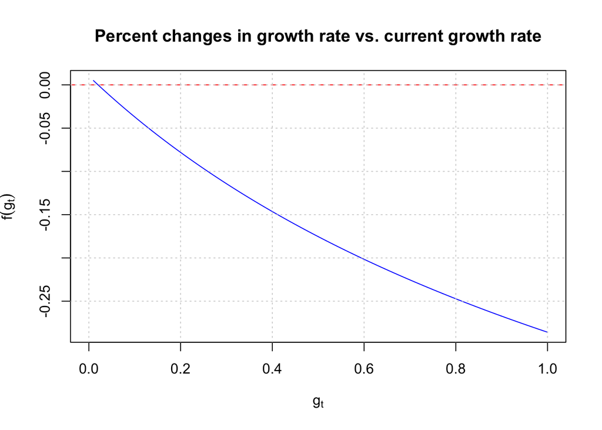

```r
f_gt <- function(g, n, gamma, theta) {
  ((1 + n)^gamma / (1 + g)^(1 - theta)) - 1
}

gt_values <- seq(0.01, 1, by = 0.001)

f_values <- f_gt(gt_values, n = 0.02, gamma = 0.5, theta = 0.5)

plot(gt_values, f_values, type = "l", col = "blue",
     xlab = expression(g[t]), ylab = expression(f(g[t])),
     main = "Percent changes in growth rate vs. current growth rate",
     xlim = c(0, max(gt_values)), ylim = c(min(f_values), max(f_values)))

abline(h = 0, lty = 2, col = "red")
grid()
```

The plot assumes values of $n = 0.02$, $\gamma = 0.5$, and $\theta = 0.5$. We see that $f(g)$, the percent changes in the technology growth rate across years, is strictly decreasing in current technology growth rate, $g$.

### 2(c)

Suppose $\theta = 0$ and $\gamma = 1$. To find the long-run steady-state technology growth rate, $g^*$, we know that the percent change in that growth rate is zero, i.e.
$$f(g^*) =
0$$
Thus,
$$f(g^*) = \left[
\frac{(1+n)^{\gamma}}{(1+g^*)^{1-\theta}}-1\right] = 0$$
$$\frac{(1+n)}{(1+g^*)} = 1$$
$$g^* = n$$
Therefore, we see that in the long-run, the steady-state growth rate of $A_t$, $g^*$, will be equal to the population growth rate $n$ if $\gamma = 1$ and $\theta = 0$.

### 2(d)

We will now solve for the long-run steady-state growth rate of $A_t$ assuming $0 < \theta < 1$ and $\gamma > 0$. Again, we know that $f(g^*) = 0$ in steady-state, so
$$\left[
\frac{(1+n)^{\gamma}}{(1+g^*)^{1-\theta}}-1\right] = 0$$
$$\frac{(1+n)^{\gamma}}{(1+g^*)^{1-\theta}} =
1$$
$$(1+n)^{\gamma} =
(1+g^*)^{1-\theta}$$
$$g^* = \left[
1+n\right]^{\frac{\gamma}{1-\theta}}-1$$

From this equation, it is evident that $g^*$ increases with the population growth rate $n$ will increase $g^*$ since the exponent $\frac{\gamma}{1-\theta} > 0$. Further, since the exponent increases with both $\gamma$ and $\theta$, we notice that $g^*$ is increasing in $\gamma$ and $\theta$ as well if $n > 0$.

### 2(e)

The model will converge to this long-run steady-state growth rate if there exists some $g^*$ such that $f(g^*) = 0$ and $g^* > 0$. If $0 < \theta < 1$, then the solution $g^*$ exists and is positive only if the population growth rate $n$ is positive since the exponent $\gamma/(1-\theta) > 0$.

If $\theta = 0$, we see that $g^* = (1+n)^\gamma - 1$ in the steady-state, and $g^* = n$ if we further restrict $\gamma = 1$. Thus, for all $0 \leq \theta < 1$, there is a solution $g^* > 0$ to $f(g^*) = 0$ if $n>0$. In other words, there exists a steady-state technology growth rate the economy converges to if the population growth rate is positive and $0 \leq \theta < 1$.

### 2(f)

We observe that
$$g_{t+1} =
B(a_LL_{t})^{\gamma}A_{t}^{\theta-1} -1$$
This implies that the growth rate of technology will jump immediately up in the short run in response to an increase in $a_L$.

To assess the long-run effect of this increase, we see that $f(g)$ does not depend on $a_L$, but only on the population growth rate, the current technology growth rate, and the parameters of the model. Thus, since $f(g)$ remains unchanged by the increase in $a_L$, there will be no long-run movement in the technology growth rate $g^*$. After the immediate increase, $g$ will gradually drop to the pre-increase steady-state level.

With the dynamics of the technology growth rate, we see that $A_t$ will begin growing quicker in the short run and then gradually level off until it is growing at the same rate it was before the increase in $a_L$. $A_t$ will then continue to grow at this constant rate $g^*$.

### 2(g)

If $\theta > 1$, then we notice that the percent change in the growth rate of technology $f(g)$ is increasing in $g$. This implies that if $g_t$ is higher, the jump up to $g_{t+1}$ will be even higher than if $g_t$ were lower assuming $g_t > 0$. Therefore, if $\theta > 1$, then the growth rate of technology will not converge to a positive value in the long-run assuming population growth is positive.

Empirical evidence suggests that $\theta > 1$ because technology has been growing at a sustained exponential rate in recent decades. The creation of new technology feeds into the production of future technology, so technology growth is accelerating.

## Problem 3: Intertemporal Consumption

### 3(a)

The budget constraints for each period are
$$C_1 = W - A$$
$$C_2 = (1+r)A$$
Substituting $A = \frac{C_2}{1+r}$ into the budget constraint for the first period, we have the lifetime budget constraint
$$C_1 + \frac{C_2}{1+r} = W$$

### 3(b)

Let $R = 1+r$. The budget constraint then becomes
$$C_1 + \frac{C_2}{R}
= W$$
We want to choose savings $A$ to maximize the utility across both periods,
$$U(C_1, C_2) = U(C_1) + \beta
U(C_2)$$
plugging in our budget constraints in terms of savings $C_1 = W - A$ and $C_2 = RA$, our problem becomes to choose $A$ in order to maximize
$$U(W-A) + \beta U(RA)$$
Taking the first derivative of this expression with respect to $A$ and setting it to zero yields the Euler equation:
$$\frac{dU}{dA} = -U'(W-A) +
\beta U'(RA)\cdot R = 0$$
$$U'(W-A) = R\beta U'(RA)$$
$$U'(C_1) = R\beta U'(C_2)$$
Substituting the derivatives, we find that the optimal consumption satisfies
$$C_1^{-\gamma} =
R\beta C_2^{-\gamma}$$
$$C_2^{\gamma}
= R\beta C_1^{\gamma}$$
$$C_2 =
(R\beta)^{\frac{1}{\gamma}}C_1$$
$$C_2
= (R\beta)^{\sigma}C_1$$
The elasticity of $C_2/C_1$ with respect to $R$ is defined as the derivative of log $C_2/C_1$ with respect to log $R$, which is equal to $\sigma$ since
$$\ln{C_2} = \sigma\ln{(R\beta)}$$

### 3(c)

Since both $C_1$ and $C_2$ increase linearly with $W$, the elasticity of consumption with respect to the first period wage $W$ is equal to $1$ for both $C_1$ and $C_2$.

### 3(d)

An increase in the discount factor $\beta$ means that the utility of second period consumption is now discounted less or, in other words, is worth more. This symbolizes that households now prefer to save more in the first period and consume it in the second period instead. The quantity that the household saves, $A$, is given by
$$A = W - C_1 = W\left[1 -
\frac{1}{1+ (1+r)^{\sigma-1}\beta^{\sigma}}\right]$$
If $\beta$ increases, since $\sigma > 0$, $A$ will increase as well. Correspondingly, first period consumption $C_1$ will decrease as well. The extra wealth saved will then be consumed in the second period, increasing $C_2$.

### 3(e)

Rearranging the budget constraint to express $C_2$ in terms of $C_1$, we have
$$W = C_1 + \frac{C_2}{1+r}$$
$$C_2 = (1+r)(W - C_1)$$
$$C_2 = -(1+r)C_1 + (1+r)W$$
Thus, the slope of our budget constraint is given by $-(1+r)$ which will increase in magnitude (become more negative) as $r$ increases. The $y$-intercept represents the amount of consumption possible if all wages are saved and then spent, along with the accumulated interest, in period two. This is equal to the value of the wages plus interest, $(1+r)W$. The $x$-intercept, in turn, represents consumption if all wages are spent in the first period itself, which is equal to $W$ regardless of the interest rate.

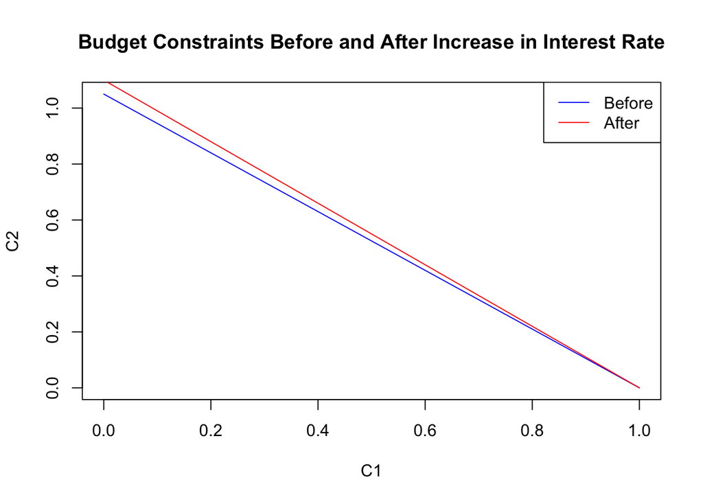

```r
budget_constraint <- function(C1, W, r) {
  return(-(1 + r) * C1 + W * (1 + r))
}

W <- 1
r1 <- 0.05
r2 <- 0.1

C1_values <- seq(0, W, length.out = 100)

C2_values_r1 <- budget_constraint(C1_values, W, r1)
C2_values_r2 <- budget_constraint(C1_values, W, r2)

plot(C1_values, C2_values_r1, type = "l", col = "blue",
     main = "Budget Constraints Before and After Increase in Interest Rate",
     xlab = "C1", ylab = "C2")

lines(C1_values, C2_values_r2, col = "red")
legend("topright", legend = c("Before", "After"), col = c("blue", "red"), lty = 1)
```

In the chart above, the wage $W$ is normalized to 1. Thus, the $y$-intercept is equal to $(1+r)$ before the interest rate increase, and increases to $(1+r^*)$ after where $r^* > r$. The $x$-intercept is simply $W = 1$. The slope of the budget constraint goes from $-(1+r)$ to $-(1+r^*)$ becoming steeper and more negative, suggesting that every unit of period one consumption is associated with a greater cost in forgone period two consumption after the rate increase.

We observe that after the interest rate increase, our new budget constraint is steeper and is greater than or equal to the previous budget constraint at every point. This tells us that the agent can now get more period two consumption than they could before holding period one consumption fixed, unless they spent it all in the first period.

Algebraically, we see from our expressions that the quantity of consumption in period 1 is indeterminate following an increase in $r$ since it depends on whether $\sigma > 1$ or $\sigma < 1$. However, period two consumption will increase regardless because of the $(1+r)$ term in the numerator.

### 3(f)

Consider the expression for the optimal quantity of period one consumption
$$C_1 = \frac{W}{1+
(1+r)^{\sigma-1}\beta^{\sigma}}$$

If $0 < \sigma < 1$, then $\sigma - 1 < 0$, which implies that an increase in $r$ would decrease the denominator of the expression. This implies that $C_1$ would increase.

If $\sigma = 1$, then $C_1$ no longer depends on $r$. Thus, when we have log-utility, after the rate increase, period one consumption will not change.

If $\sigma > 1$, then $\sigma - 1 > 0$, which implies that an increase in $r$ would increase the denominator of the expression. This implies that $C_1$ would decrease.

Thus, the change in period one consumption following an increase in the interest rate depends on the value of the intertemporal-elasticity of substitution $\sigma$.